# The toxFigures function

Brie Noble, Blake Langlais

# Introduction

The `toxFigures()` function creates publication quality longitudinal bar charts of symptomatic AE profiles. Frequency distributions of PRO-CTCAE scores can be shown over the course of the trial and can be stratified by treatment arm. An R list object is returned with the available PRO-CTCAE items indexed as elements of the list beside a reference table. Each figure item is a ggplot2 object.

```r
library(ProAE)
require(knitr)

data(tox_acute)
```

In the following examples, we will use the provided `ProAE::tox_acute` data frame. This data was simulated to demonstrate a common symptomatic AE profile where the drug group experiences acute toxicity followed by symptom abatement over the course of treatment.

In order to use the `toxFigures()` function the data frame needs to be in long format (multiple rows per patient). Additionally, the cycle variable needs to be numeric. This data frame already has composite scores calculated. If this wasn’t the case then we could use the `toxScores()` function to calculate the scores first. Alternatively, if your data frame only included frequency/severity PRO-CTCAE items the output would only include Frequency/Severity bar charts.

# Example 1 - Standard Longitudinal Bar Chart

```r
acute <- tox_acute

str(acute)
```

```
'data.frame':   1400 obs. of  7 variables:
 $ id             : int  1 1 1 1 1 1 1 1 1 1 ...
 $ Cycle          : int  1 2 3 4 5 6 7 8 9 10 ...
 $ arm            : chr  "Drug" "Drug" "Drug" "Drug" ...
 $ PROCTCAE_9A_SCL: num  0 2 4 0 0 0 0 0 0 0 ...
 $ PROCTCAE_9B_SCL: num  0 2 3 3 0 1 0 0 0 0 ...
 $ PROCTCAE_9_COMP: num  0 2 3 0 0 0 0 0 0 0 ...
 $ time           : chr  "Cycle 1" "Cycle 2" "Cycle 3" "Cycle 4" ...
```

Next, we can use the `toxFigures()` function to create the standard longitudinal bar chart.

The acute data frame only has one item - Nausea, so the returned list only has one item.

```r
figure_1 <- toxFigures(dsn = acute,
                      cycle_var = "Cycle",
                      baseline_val = 1,
                      arm_var = "arm",
                      id_var = "id")
```

```
  PRO_AE item_index
1 Nausea          1
```

```r
figure_1[[1]][2]
```

[[1]]

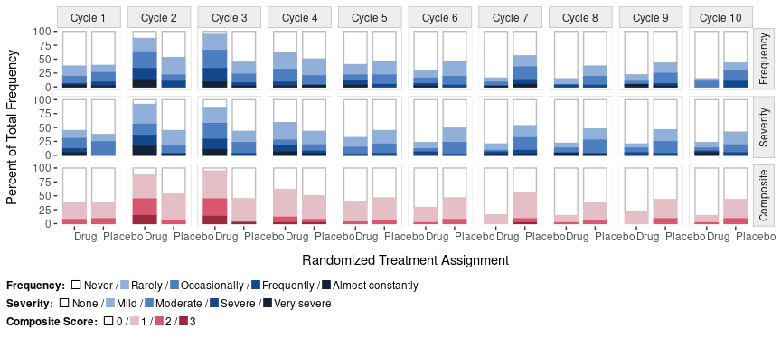

# Example 2 - Customizing bar charts

Multiple customization parameters can be added to the `toxFigures()` call to customize the appearance of the output.

Here are some examples:

1. easily add the item name as the title by setting the parameter `add_item_title` to `TRUE`
2. add annotations to the bars to show the number of patient with nausea scores of 3 or greater using the `bar_label` parameter
3. include only certain cycles or time points using the `cycle_vals` parameter
4. customize the cycle labeling by setting the `cycle_label` parameter to `TRUE` and using the `cycle_labs` to specify the labels
5. choose a colorblind-friendly color palette using the `colors` parameter
6. modify the x-axis title
7. include a box around the summary measures setting the `summary_highlight` parameter to `TRUE`
8. adjust the appearance of the x-axis labels angle using the `x_lab_angle` and the `x_lab_hjust` parameter

```r
figure_2 <- toxFigures(dsn = acute,
                      cycle_var = "Cycle",
                      baseline_val = 1,
                      arm_var = "arm",
                      add_item_title=TRUE, #1
                      bar_label = 3, #2
                      cycle_vals=c(1,2,3,4,5,6), #3
                      cycle_label=TRUE,
                      cycle_labs=c("Baseline",
                                   "Week 1",
                                   "Week 2",
                                   "Day 30",
                                   "Month 2",
                                   "Month 3"
                                   ), #4
                      colors = 2, #5
                      id_var = "id",
                      x_label = "Assigned Treatment Group",  #6
                      summary_highlight = TRUE, #7
                      x_lab_angle=45,
                      x_lab_hjust=1) #8
```

```
  PRO_AE item_index
1 Nausea          1
```

```r
figure_2[[1]][2]
```

[[1]]

[figure not shown]